# Data analysis based on the sample from DATA2X02 students

Mingze Gong (SID:490284045)

23/09/2020

# 1 Executive Summary

By launching a survey including a series of questions on ed, we obtain the data from our a sample of DATA2X02 students enrolled in Semester2, 2020.

To begin with, we describe our sample and our target population See(3.1).

Also, the principle, **Rubbish in-Rubbish out**, holds true especially in a survey expecting for some useful data from the sample. Therefore, we took a careful look at the questions for interviewees and brought some suggestions up (See 3.2.3) .

Then, after examining whether the time of testing for covid-test follows a **Poisson distribution** (See 5.1), we conducted a test for independence in a contingency table and two other tests including a test for **Independence** (See 5.2) as well as a **One sample t-test** (See 5.3).

# 2 Findings

1. Although it is a random sample of DATA2X02 students, we believe some potential biases such as **non-response bias** and **measurement bias** do exist wheras **selection biases** is really not our concern in this case.
2. As for the questions for interviewees, we do think that choices could be provided for some questions that normally are not quite subjective in terms of answers to them.
3. Gievn that **p-value** (See 5.1) is too small, we reject our null hypothesis $H_0$ but favor $H_1$ which is the number of COVID tests does not come from a Poisson distribution.
4. Due to the slightly larger p-value compared to $\alpha = 0.05$, we do not reject the null hypothesis. So we believe there is not sufficiently enought evidence suggesting that floss frequency is related to the gender of DATA2X02 classmates.
5. After choosing $\mu_0 = 5.1$ which comes from a report of [**American Psychological Association**](https://www.apa.org/about) in 2015 in terms of adults’ stress level, the p-value from the t-test is too small even less than $\alpha$. We then reject $H_0$ and accept $H_1$ which implies that DATA2X02 students’ stress level is not equal to 5.1.
6. The relationship between two variables can be broken up and even reversed when introducing a third variable.

# 3 Introduction

## 3.1 Population description

The result of this survey is utilized to make inferences for students enrolled in DATA2X02 in Semester 2, 2020, which means that these people are our target population in this research. Then we initiated a questionnaire through Ed which is a forum where students and teaching staff can communicate with each other in terms of any sorts of relevant questions. Finally, based on data from students who finished the online questionnaire (our sample), we conduct further analysis using R language with the help of RStudio.

## 3.2 Part of equired questions (1-3) for this report

### 3.2.2 What are the potential biases? Which variables are most likely to be subjected to this bias?

As Tarr (2020.a) states, there are three types of bias including selection bias, non-response bias and measurement bias that researchers need to pay close attention to when dealing with data from a survey. If potential biases do exist in this research, they could be non-response bias and measurement bias. This non-mandatory study follows a relatively random procedure and we target on DATA2X02 students which is absolutely related with our aim. However, one of the potential biases mentioned above, non-response bias, derives from the fact not all DATA 2X02 students would log into ed and, more importantly, actually receive a notification of this survey. Although all students, for some reasons, do know the research gets underway, we could not promise that they are in an appropriate state of answering those questions. For example, we found that someone answers nothing but still hands in his/her questionnaire. Many questions have been affected by such problem including gender and dominant hand questions. Also, someone may give their exact answers but not in a rational way. The questions in terms of eye color and the amount of time spent on university work are more or less affected. This is actually prevalent in our dataset so that we need to clean them and exclude these disturbances.As for measurement bias, we believe that the respondents worry whether all data are leaked or not and this concern might lead them to answer the questions in a way that they think is bearable even in public. For example, the question with regard to private hygiene or healthy state (How often do you floss your teeth and Do you have asthma) may induce such issue.

### 3.2.3 Are there any questions that needed improvement to generate useful data?

We can make further improvements on mainly 2 sides.

1. Offering some question answers multiple choices such as shoe-size or eye-color. For some questions that are not too subjective, we could offer a few choices, which would contribute much help in later analysis because this will not only save much time for investigators to make data more uniform, but also imply interviewees that this questionnaire will not take long time to finish. In the end, we collect more responses but spend less time organizing them which gives way to interpreting the results.
2. Improving the internal connection among designed questions. The question about stress level was designed to, for example, study what triggers the stress. We believe that it may be related to study load both financially and mentally, which may urge them to get a part-time job that may unexpectedly impose much more pressure on themselves. However, both study load and workload are measured in terms of last semester’s whereas the stress level result comes from last week.

# 4 Before analysis

## 4.1 Import the data

```r
#knitr::write_bib(c("janitor","dplyr", "skimr", "visdat", "data.table", "bookdown", "kableExtra", "ggplot2"), "packages.bib")
#citation("tidyverse")
#citation("gendercodeR")
```

```r
raw = readr::read_csv("https://docs.google.com/spreadsheets/d/e/2PACX-1vTf8eDSN_2QbMTyVvO5bdYKZSEEF2bufDdYnLnL-TsR8LM-6x-xu1cxmDMohlbLrkMJn9DE7EG7pg5P/pub?gid=1724783278&single=true&output=csv")
```

## 4.2 Clean coulumn names

```r
tibble(Position = 1:21, `Column names` = colnames(raw)) %>%
gt::gt() %>%
gt::tab_source_note("Table 1: Questions asked in the DATA2002 survey.")
```

Here we have original questions in the questionnaire:

```r
tibble(Position = 1:21, `Column names` = colnames(raw)) %>%
gt::gt() %>%
gt::tab_source_note("Table 1: Questions asked in the DATA2002 survey.")
```

**Click to have a look**

| Position | Column names |
| --- | --- |
| 1 | Timestamp |
| 2 | How many times have you been tested for COVID? |
| 3 | Gender |
| 4 | Postcode of where you live during semester |
| 5 | How long has it been since you last went to the dentist? |
| 6 | On average, how many hours per week did you spend on university work last semester? |
| 7 | What is your favourite social media platform? |
| 8 | Did you have a dog or a cat when you were a child? |
| 9 | Do you currently live with your parents? |
| 10 | How many hours a week do you spend exercising? |
| 11 | What is your eye colour? |
| 12 | Do you have asthma? |
| 13 | On average, how many hours per week did you work in paid employment in semester 1? |
| 14 | What is your favourite season of the year? |
| 15 | What is your shoe size? |
| 16 | How tall are you? |
| 17 | How often do you floss your teeth? |
| 18 | Do you wear glasses or contacts? |
| 19 | What is your dominant hand? |
| 20 | How do you like your steak cooked? |
| 21 | On a scale from 0 to 10, please indicate how stressed you have felt in the past week. |

Table 1: Questions asked in the DATA2002 survey.

Firstly, we use **janitor package** (Firke 2020) to make the column names look more concise.

```r
x = raw %>% janitor::clean_names()
tibble(Position = 1:21, `Column names` = colnames(x)) %>%
gt::gt() %>%
gt::tab_source_note("Table 2: Column names after janitor.")
```

**Click to have a look**

| Position | Column names |
| --- | --- |
| 1 | timestamp |
| 2 | how_many_times_have_you_been_tested_for_covid |
| 3 | gender |
| 4 | postcode_of_where_you_live_during_semester |
| 5 | how_long_has_it_been_since_you_last_went_to_the_dentist |
| 6 | on_average_how_many_hours_per_week_did_you_spend_on_university_work_last_semester |
| 7 | what_is_your_favourite_social_media_platform |
| 8 | did_you_have_a_dog_or_a_cat_when_you_were_a_child |
| 9 | do_you_currently_live_with_your_parents |
| 10 | how_many_hours_a_week_do_you_spend_exercising |
| 11 | what_is_your_eye_colour |
| 12 | do_you_have_asthma |
| 13 | on_average_how_many_hours_per_week_did_you_work_in_paid_employment_in_semester_1 |
| 14 | what_is_your_favourite_season_of_the_year |
| 15 | what_is_your_shoe_size |
| 16 | how_tall_are_you |
| 17 | how_often_do_you_floss_your_teeth |
| 18 | do_you_wear_glasses_or_contacts |
| 19 | what_is_your_dominant_hand |
| 20 | how_do_you_like_your_steak_cooked |
| 21 | on_a_scale_from_0_to_10_please_indicate_how_stressed_you_have_felt_in_the_past_week |

Table 2: Column names after janitor.

However, the prefixes of names above such as *what_is_your* or *did_you* or *how_many* still look so redundant. We then remove such things by `stringr::str_replace()`. At the same time, we manually shorten some names.

```r
colnames(x) = stringr::str_replace(string = colnames(x),
                                   pattern = "what_is_your_",
                                   replacement = "")
colnames(x) = stringr::str_replace(string = colnames(x),
                                   pattern = "on_average_how_many_hours_per_week_did_you_",
                                   replacement = "")
colnames(x)[2] = "covid_test"
colnames(x)[4] = "postcode"
colnames(x)[5] = "dentist"
colnames(x)[6] = "university_work"
colnames(x)[7] = "social_media"
colnames(x)[8] = "dog_or_cat"
colnames(x)[9] = "live_with_parents"
colnames(x)[10] = "exercising"
colnames(x)[12] = "asthma"
colnames(x)[13] = "paid_work"
colnames(x)[14] = "fav_season"
colnames(x)[16] = "height"
colnames(x)[17] = "floss_frequency"
colnames(x)[18] = "glasses"
colnames(x)[20] = "steak_preference"
colnames(x)[21] = "stress_level"
```

Then we have basically finished renaming the column names.

```r
tibble(Position = 1:21, `Variable name` = colnames(x), `Corresponding question` = colnames(raw)) %>%
  gt::gt() %>%
  gt::tab_source_note("Table 3: Variable names and the corresponding questions asked in the DATA2002 survey.")
```

**Click to have a look**

| Position | Variable name | Corresponding question |
| --- | --- | --- |
| 1 | timestamp | Timestamp |
| 2 | covid_test | How many times have you been tested for COVID? |
| 3 | gender | Gender |
| 4 | postcode | Postcode of where you live during semester |
| 5 | dentist | How long has it been since you last went to the dentist? |
| 6 | university_work | On average, how many hours per week did you spend on university work last semester? |
| 7 | social_media | What is your favourite social media platform? |
| 8 | dog_or_cat | Did you have a dog or a cat when you were a child? |
| 9 | live_with_parents | Do you currently live with your parents? |
| 10 | exercising | How many hours a week do you spend exercising? |
| 11 | eye_colour | What is your eye colour? |
| 12 | asthma | Do you have asthma? |
| 13 | paid_work | On average, how many hours per week did you work in paid employment in semester 1? |
| 14 | fav_season | What is your favourite season of the year? |
| 15 | shoe_size | What is your shoe size? |
| 16 | height | How tall are you? |
| 17 | floss_frequency | How often do you floss your teeth? |
| 18 | glasses | Do you wear glasses or contacts? |
| 19 | dominant_hand | What is your dominant hand? |
| 20 | steak_preference | How do you like your steak cooked? |
| 21 | stress_level | On a scale from 0 to 10, please indicate how stressed you have felt in the past week. |

Table 3: Variable names and the corresponding questions asked in the DATA2002 survey.

## 4.3 Totally missing Values

We can visualize the completeness of the data in **visdat package** (Tierney 2017). As is shown in Figure 4.1, many values are lost due to the fact that someone answered nothing but still submitted. We had better remove some completely empty rows in the dataset.

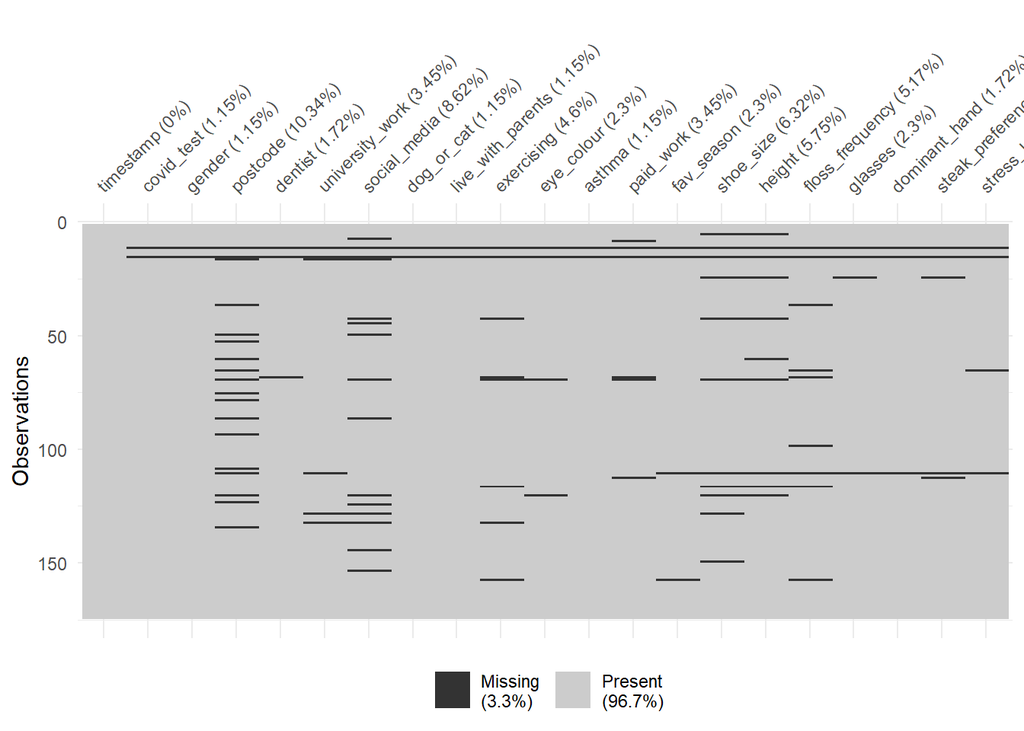

Figure 4.1: Visualising the completeness of the data.

```r
visdat::vis_miss(x)
```

```r
x_withoutcpna = x %>% drop_na(covid_test)
```

Although, there are still many missing values as was shown in Figure 4.2, removing all the rows including *NA* will unavoidably make us lose some useful values that these students filled in before.**Therefore, we would not delete them all at a time. Instead, when conducting some relevant tests, we would decide if there is *NA* disturbance and whether the data in hand is answered in a rational way.** For now, we remove the data submitted by students who actually did not answer anything.

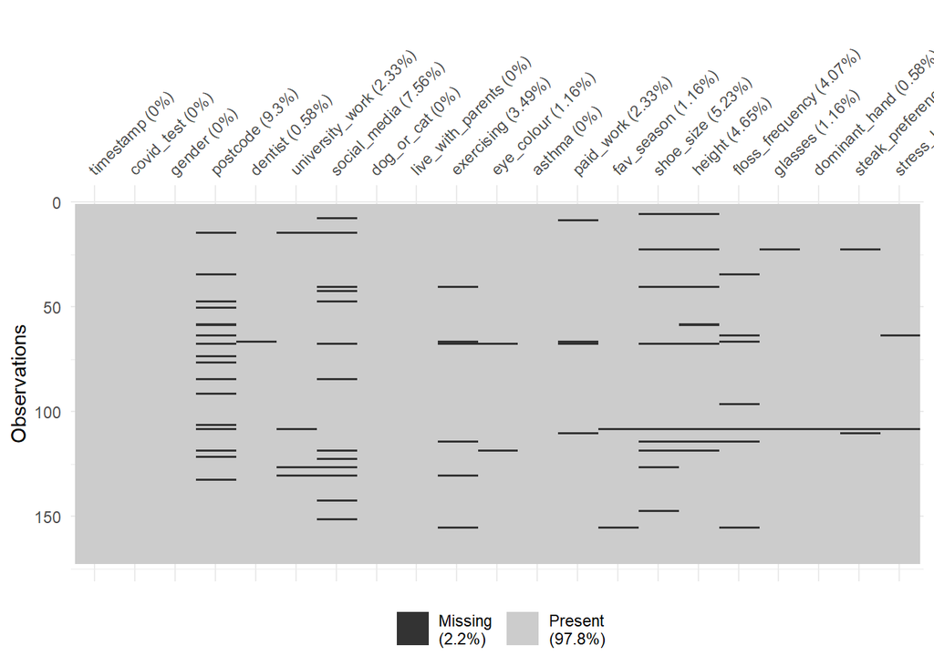

Figure 4.2: Visualising the completeness of the data after initial removing

```r
visdat::vis_miss(x_withoutcpna)
```